# 2. 다중분류 분류 리포트 해석 및 모델 개선

### 이번 작업에 포함된 내용

```python
# 메모리내 변수 제거

all = [var for var in globals() if var[0] != "_"]   # globals() 목록의 첫글자가 _ 로 시작하지 않는 자료의 리스트만 가져와서
for var in all:
    del globals()[var]    # _로 시작하지 않는 모든 자료 삭제함
```

## [F1 스코어등에 대한 이해, 아래 사이트의 38페이지 부터]

https://books.google.co.kr/books?id=jxfpDwAAQBAJ&pg=PA41&lpg=PA41&dq=f1+%EA%B0%80%EC%A4%91%EC%B9%98%ED%8F%89%EA%B7%A0&source=bl&ots=zAdfB1s-xL&sig=ACfU3U2dPsQNKHuSshzF4ONORFDsLZmEDQ&hl=ko&sa=X&ved=2ahUKEwjBp4-I0LLzAhWPxYsBHYo5ANAQ6AF6BAgdEAM#v=onepage&q=f1%20%EA%B0%80%EC%A4%91%EC%B9%98%ED%8F%89%EA%B7%A0&f=false

## 다중클래스에서의 정밀도, 재현율등 계산법

```
[[1 2 0]
 [0 1 0]
 [0 1 2]]
```

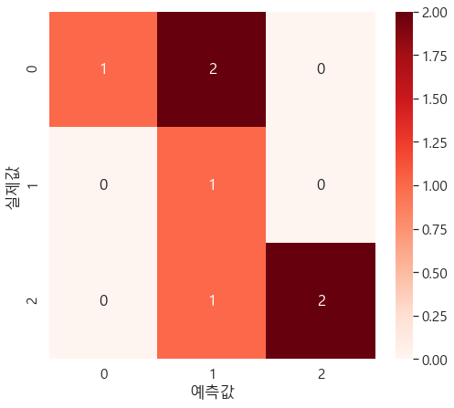

```python
import numpy as np

y_true = np.array([0, 0, 0, 1,2,2,2])
y_pred = np.array([0, 1, 1, 1,1,2,2])

from sklearn.metrics import confusion_matrix
cm=confusion_matrix(y_true,y_pred)
print(cm)

## 히트맵으로 시각화하기
from matplotlib import font_manager, rc
font_name = font_manager.FontProperties(fname="c:/Windows/Fonts/malgun.ttf").get_name()
rc('font', family=font_name)

plt.figure(figsize=[8,7])
sns.heatmap(cm, cmap='Reds', annot=True, fmt='.0f')
plt.xlabel('예측값')
plt.ylabel('실제값')
plt.show()
```

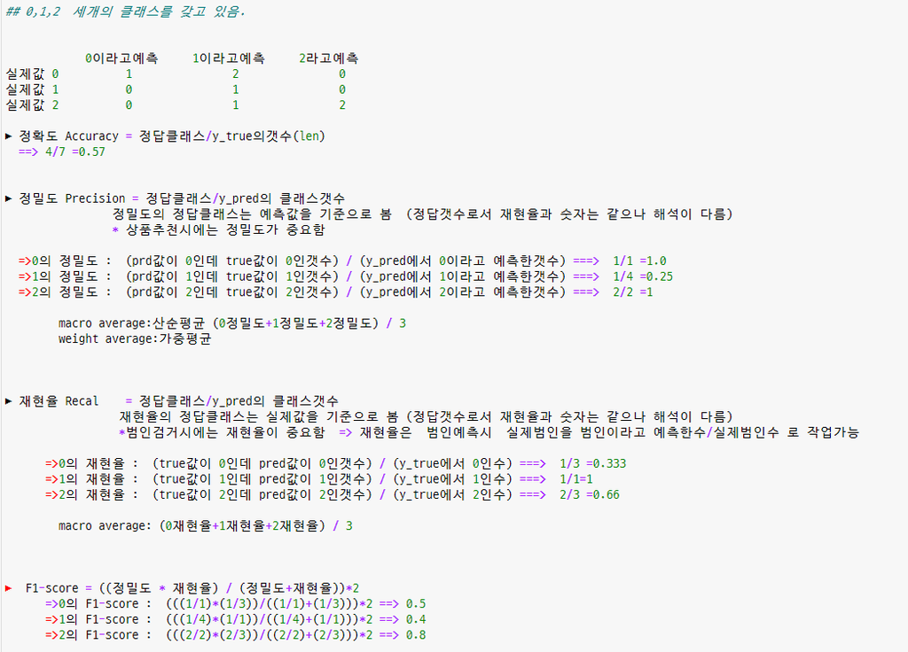

### [f1스코어]

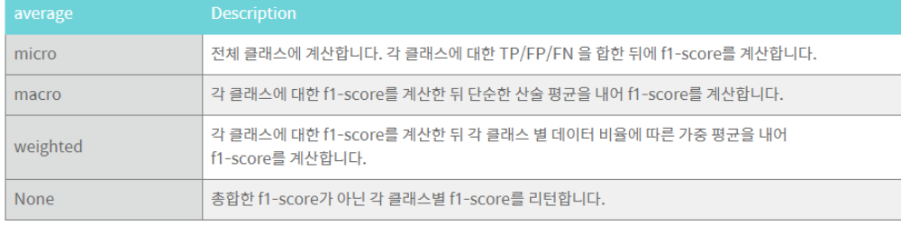

클래스 불균형(Imbalance) 문제가 있는 데이터셋에서는 Micro-average가 조금 더 효과적인 평가지표가 됨.

```python
from sklearn.metrics import f1_score

print('f1 score / micro: %0.3f'%f1_score(y_true,y_pred,average='micro'))
print('f1 score / macro: %0.3f'%f1_score(y_true,y_pred,average='macro'))
print('f1 score / weighted: %0.3f'%f1_score(y_true,y_pred,average='weighted'))
print(f1_score(y_true,y_pred,average=None))   # 혼돈행렬의 0, 1, 2 값의 f1-score임
```

```
f1 score / micro: 0.571
f1 score / macro: 0.567
f1 score / weighted: 0.614
[0.5 0.4 0.8]
```

```python
from sklearn.metrics import classification_report
print(classification_report(y_true, y_pred))
```

```
              precision    recall  f1-score   support

           0       1.00      0.33      0.50         3
           1       0.25      1.00      0.40         1
           2       1.00      0.67      0.80         3

    accuracy                           0.57         7
   macro avg       0.75      0.67      0.57         7
weighted avg       0.89      0.57      0.61         7
```

### [정밀도 높이기]

- 위에서 확인한바와 같이
- 정밀도는 예측값과 실제값이 같으며 / 예측한 값의 갯수 로 나누었음
- 이러한 정밀도를 높이기 위한 방법으로는 y값과 y의 예측값을 같은 값이 아닌 일정한 범위를 주어서 같은 값으로 치환하면 됨

```python
# y예측값과 y값이 같은값일때만
precise_accuracy = np.sum(y_pred == y_true) / len(y_pred)

# y예측값과 y값의 차이가 1이하일때는 같은값으로 봄 (abs는 절대값)
adjacent_accuracy = np.sum(np.abs(y_pred - y_true) <= 1) / len(y_pred)

print('------- 정밀도 ----------')
print(precise_accuracy)

print('\n-------- 인접율 --------')
print(adjacent_accuracy)
```

```
------- 정밀도 ----------
0.5714285714285714

-------- 인접율 --------
1.0
```